# Tutorial 8

Swarag

2023-10-30

# Statistical Models - why we want to estimate $f$?

- $\textbf{Prediction:}$ In many situations, a set of inputs $X$ are readily available, but the output $Y$ cannot be easily obtained. In this setting, since the error term averages to zero, we can predict $Y$ using $\hat{Y} = \hat{f}(X)$
- $\hat{f}$ is the estimation of f.
- In this setting, $\hat{f}$ is often treated as a black box, in the sense that one is not typically concerned with the exact form of $\hat{f}$, provided that it yields accurate predictions for Y .

# Statistical Models - why we want to estimate $f$?

- $\textbf{Inference:}$ We are often interested in understanding the way that $Y$ is affected as $\{X_{1}, . . . , Xp\}$ change.
- In this situation we wish to estimate $f$ , but our goal is not necessarily to make predictions for $Y$.
- Now $\hat{f}$ cannot be treated as a black box, because we need to know its exact form.

# Linear Models - the simplest one

# Reducible And Irreducile Errors

- $\textbf{Reducible error :} E(f(X) - \hat{f}(X))^2$
- $\textbf{irreducible error :} Var(\epsilon)$
- $E(Y − \hat{Y} )^2$ represents the average, or expected value, of the squared expected value difference between the predicted and actual value of $Y$.
- $Var(\epsilon)$ represents the variance associated with the error term.

# Estimating $\hat{f}$; Parametric Approach

- Firstly, we will make assumptions about the functional form of $f$. The simplest one is that $f$ is linear, that is:
- $f(X) = \beta_{0} + \beta_{1}X_{1} + ... + \beta_{p}X_{p}$
- Here in the simplest case, we would be using the ordinary least square method for finding the linear model.
- $\textbf{Caution:}$ least square method is one of many method used for finding $\hat{f}$

# Least Square Method: An Optimization Problem??

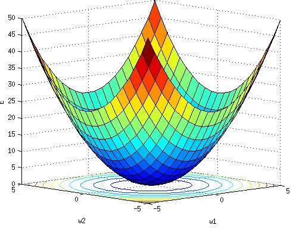

- What are we optimizing?

# Optimizing Error

- $s(\beta_{0}, \beta_{1}) = \sum_{i = 1}^{n} (y_{i} - \hat{f}(x_{i})) = \sum_{i = 1}^{n} (y_{i} - \beta_{0} - \beta_{1}x_{i})^2$
- $(\frac{d(s(\beta_{0},\beta_{1}))}{d(\beta_{0})})_{\hat{\beta_{0}},\hat{\beta_{1}}} = -2\sum_{i = 1}^{n} (y_{i} - \hat{\beta_{0}} - \hat{\beta_{1}}x_{i}) = 0$
- $(\frac{d(s(\beta_{0},\beta_{1}))}{d(\beta_{1})})_{\hat{\beta_{0}},\hat{\beta_{1}}} = -2 \sum_{i = 1}^{n} (y_{i} - \hat{\beta_{0}} - \hat{\beta_{1}}x_{i})x_{i} = 0$

# Let’s consider the derivative w.r.t $\beta_{0}$

- $-2\sum_{i = 1}^{n} (y_{i} - \hat{\beta_{0}} - \hat{\beta_{1}}x_{i}) = 0 \implies \sum_{i= 1}^{n} y_{i} = \hat{\beta_{0}}\sum_{i= 1}^{n} 1 + \hat{\beta_{1}}\sum_{i= 1}^{n} x_{i}$
- $\sum_{i= 1}^{n} y_{i} = n\hat{\beta_{0}}+ \hat{\beta_{1}}\sum_{i= 1}^{n} x_{i} \implies \frac{1}{n}\sum_{i= 1}^{n} y_{i} = \hat{\beta_{0}} + \hat{\beta_{1}}\frac{1}{n}\sum_{i= 1}^{n} x_{i}$
- $\bar{y} = \hat{\beta_{0}} + \hat{\beta_{1}} \bar{x} \implies \hat{\beta_{0}} = \bar{y} - \hat{\beta_{1}} \bar{x}$

# Let’s consider the derivative w.r.t $\beta_{1}$

- $\sum_{i = 1}^{n} (y_{i} - \hat{\beta_{0}} - \hat{\beta_{1}}x_{i})x_{i} = 0$
- $\implies \sum_{i = 1}^{n}(y_{i}x_{i} - \hat{\beta_{0}}x_{i} - \hat{\beta_{1}}x_{i}^{2}) = 0$
- $\implies \sum_{i = 1}^{n}(y_{i}x_{i} - (\bar{y} - \hat{\beta_{1}} \bar{x})x_{i} - \hat{\beta_{1}}x_{i}^{2}) = 0$
- $\implies \sum_{i = 1}^{n}(y_{i}x_{i} - \bar{y}x_{i} + \hat{\beta_{1}} \bar{x}x_{i} - \hat{\beta_{1}}x_{i}^{2}) = 0$
- $\implies \sum_{i = 1}^{n}(y_{i} - \bar{y} + \hat{\beta_{1}} \bar{x} - \hat{\beta_{1}}x_{i})x_{i} = 0$
- $\implies \sum_{i = 1}^{n}(y_{i} - \bar{y} - \hat{\beta_{1}}(x_{i} - \bar{x})) = 0$
- $\implies \sum_{i = 1}^{n}(y_{i} - \bar{y}) = \hat{\beta_{1}}\sum_{i = 1}^{n}(x_{i} - \bar{x})$
- $\implies \hat{\beta_{1}} = \frac{\sum_{i = 1}^{n}(y_{i} - \bar{y})}{\sum_{i = 1}^{n}(x_{i} - \bar{x})} = \frac{\sum_{i = 1}^{n}(y_{i} - \bar{y})(x_{i} - \bar{x})}{\sum_{i = 1}^{n}(x_{i} - \bar{x})^2}$

# Why we bother about normal distribution of error terms?

- In a linear regression model, the normality assumption (i.e., the error term is normally distributed) NOT required for calculating unbiased estimates.
- We assume that there could be many different response values (Y) for a given value of X in the population.
- In other words, conditional on X, both Y and $\epsilon$ could take different values. Therefore, Both the response variable and the error term are random variables.

# Why we bother about normal distribution of error terms?

- $\sigma^2$ is the variance of the error term. $\sigma$ is the standard deviation of the error. This is an unknown parameter in the population model.
- $S$ (the residual standard deviation, the residual standard error, or the standard error of the regression) is the unbiased estimator of the standard deviation of the error.
- $S^2$ (the residual variance, the mean square error, or MSE) is the unbiased estimator of the variance of the error.
- $S^2 = \frac{\sum_{i=1}^{n}\epsilon_{i}}{n-k-1}$

# Why we bother about normal distribution of error terms?

- We know that OLS doesn’t require a normality assumption (e.g., the error term follows a normal distribution) to produce unbiased estimates with the minimum variance.
- Let’s consider the vector form: $Y = \beta_{0} + \beta_{1}X + \epsilon$
- $\hat{\beta_{i}}$ itself is a random variable since it varies in different sample data.
- Therefore, knowing the sampling distribution of $\hat{\beta_{i}}$ allows us to calculate p-values for significance testing and generates reliable confidence intervals for OLS estimators.
- We can show that if we assume that the errors are normally distributed in a linear regression model, the OLS estimators will be normally distributed as well.

# Normal distribution of residuals and OLS estimates

- $\hat{\beta_{1}} = (X^{'}X)^{-1} X^{'}Y$, $Y = \beta_{1}X + \epsilon$
- $\hat{\beta_{1}} = (X^{'}X)^{-1} X^{'}(\beta_{1}X + \epsilon)$
- $\hat{\beta_{1}} = (X^{'}X)^{-1} X^{'}\beta_{1}X + (X^{'}X)^{-1} X^{'}\epsilon)$
- $\hat{\beta_{1}} = \beta_{1} + (X^{'}X)^{-1} X^{'}\epsilon)$
- $\hat{\beta_{1}}$ are just a linear function of the error terms. By assuming the error terms have a multivariate normal distribution, we are also implying the OLS estimators have a multivariate normal distribution.

# Question 1

- A random sample of 11 statistics students produced the following data, where x is the third exam score out of 80, and y is the final exam score out of 200. Can you predict the final exam score of a random student if you know the third exam score?

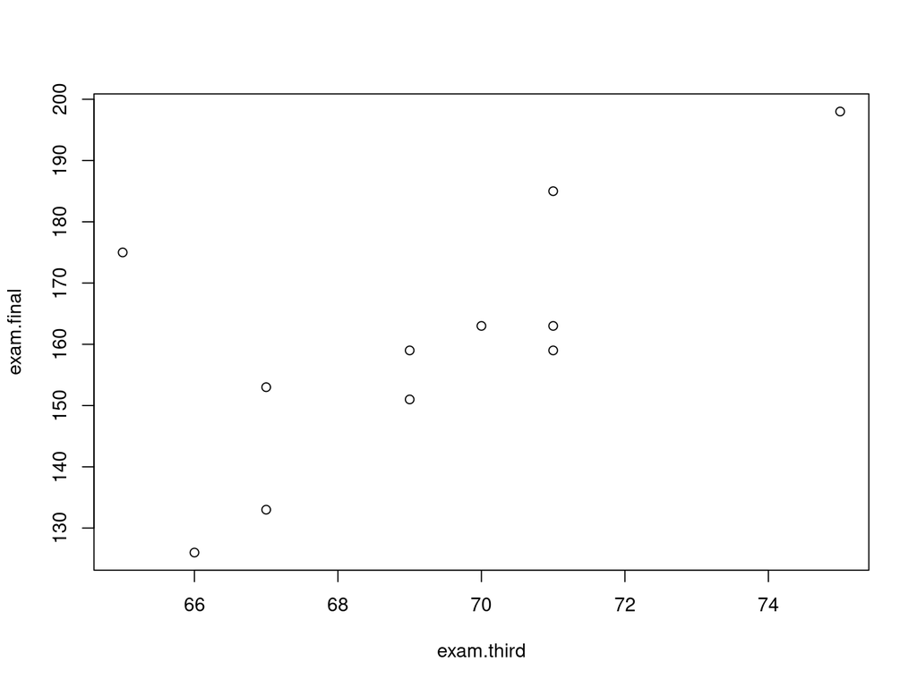

```r
exam.third <- c(65, 67, 71, 71, 66, 75, 67, 70, 71, 69, 69)
exam.final <- c(175, 133, 185, 163, 126, 198, 153, 163, 159, 151, 159)

plot(y=exam.final,x=exam.third)
```

- Now try fitting linear model using lm!

# Answer 1

- In r, the lm() command is used to estimate linear regression models. The “lm” stands for linear model.

```r
exam.lm <- lm(exam.final ~ exam.third)
summary(exam.lm)
```

```
##
## Call:
## lm(formula = exam.final ~ exam.third)
##
## Residuals:
##     Min      1Q  Median      3Q     Max
## -19.095  -9.404  -1.404   6.268  34.733
##
## Coefficients:
##             Estimate Std. Error t value Pr(>|t|)
## (Intercept) -173.513    125.765  -1.380   0.2010
## exam.third     4.827      1.816   2.658   0.0262 *
## ---
## Signif. codes:  0 '***' 0.001 '**' 0.01 '*' 0.05 '.' 0.1 ' ' 1
##
## Residual standard error: 16.41 on 9 degrees of freedom
## Multiple R-squared:  0.4397, Adjusted R-squared:  0.3774
## F-statistic: 7.063 on 1 and 9 DF,  p-value: 0.02615
```

- Do scatterplot with regression line

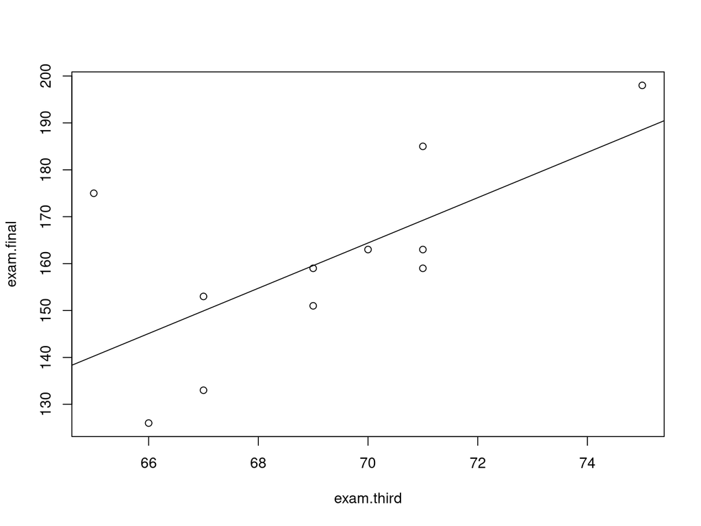

```r
plot(y=exam.final,x=exam.third)
abline(exam.lm)
```

- Residual diagnostics

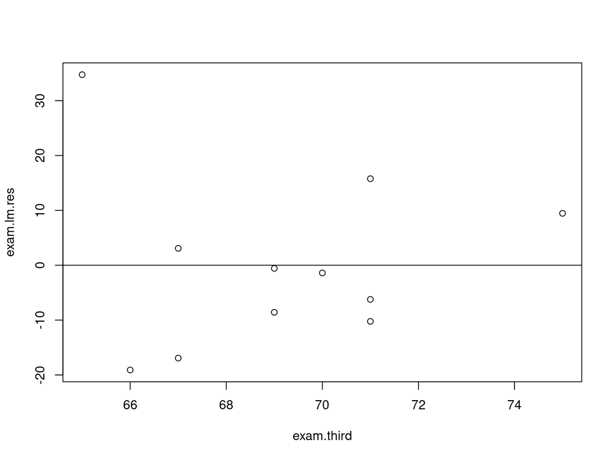

```r
exam.lm.res = resid(exam.lm)

plot(x=exam.third,y=exam.lm.res)
abline(h=0)
```

- let’s discuss

# Question 2: Model complexity

- What happens to the model as we increses model complexity?

```r
n <- 100
X <- 2 * runif(n, min = 0, max = 1)
y <- 5 * X + rnorm(n, mean = 0, sd = 1)
```

- Use “poly” function in R to change the complexity of the model, by making higher order terms

# Answer 2

- Function and code

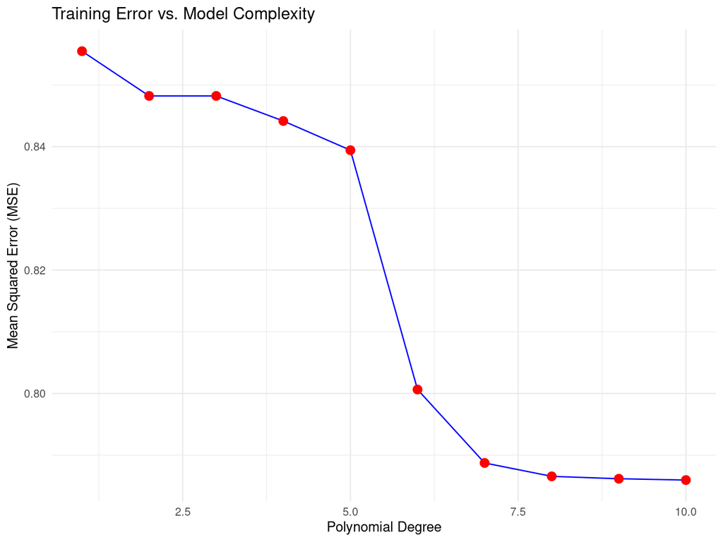

```r
set.seed(42)

# Generate synthetic data
n <- 100
X <- 2 * runif(n, min = 0, max = 1)
y <- 5 * X + rnorm(n, mean = 0, sd = 1)

# Function to fit polynomial regression and calculate MSE
fit_polynomial <- function(degree) {
  poly_features <- poly(X, degree, raw = TRUE)
  model <- lm(y ~ poly_features - 1)  # -1 removes intercept term
  predictions <- predict(model, data.frame(poly_features = poly(X, degree, raw = TRUE)))
  mse <- mean((y - predictions)^2)
  return(mse)
}

# Try different polynomial degrees
degrees <- 1:10
mse_values <- sapply(degrees, fit_polynomial)

# Plot the training error against model complexity
data <- data.frame(Degree = degrees, MSE = mse_values)
ggplot(data, aes(x = Degree, y = MSE)) +
  geom_line(color = "blue") +
  geom_point(color = "red", size = 3) +
  labs(x = "Polynomial Degree", y = "Mean Squared Error (MSE)") +
  ggtitle("Training Error vs. Model Complexity") +
  theme_minimal()
```

# Model fit vs Explainability

- What if we are getting a very good fit for an overly complicated model?
- What if the model is overfitting?
- How would we penalise for model complexity?
- Why we penalise for model complexity?

# Bias - Variance Trade off

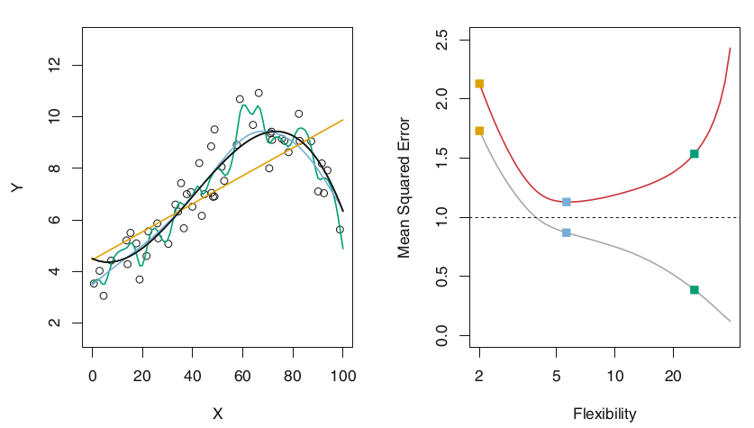

What do you observe? Why?

# Bias Variance Trade-Off

# What do we mean by $Variance$?

- $Variance$ refers to the amount by which fˆ would change if we estimated it using a diﬀerent training data set.
- Variance refers to the amount by which $\hat{f}$ would change if we estimated it using a diﬀerent training data set.
- Since the training data are used to ﬁt the statistical learning method, diﬀerent training data sets will result in a diﬀerent $\hat{f}$
- But ideally the estimate for f should not vary too much between training sets.
- In general, more ﬂexible statistical methods have higher variance.

# What do we mean by $Bias$?

- $Bias$ refers to the error that is introduced by approximating a real-life problem, which may be extremely complicated, by a much simpler model.
- For example, linear regression assumes that there is a linear relationship between $Y$ and $\{ X_1 , X_2 , . . . , X_p\}$.
- It is unlikely that any real-life problem truly has such a simple linear relationship, and so performing linear regression will undoubtedly result in some bias in the estimate of $f$
- If true $f$ is substantially non-linear, so no matter how many training observations we are given, it will not be possible to produce an accurate estimate using linear regression.

# Question 1

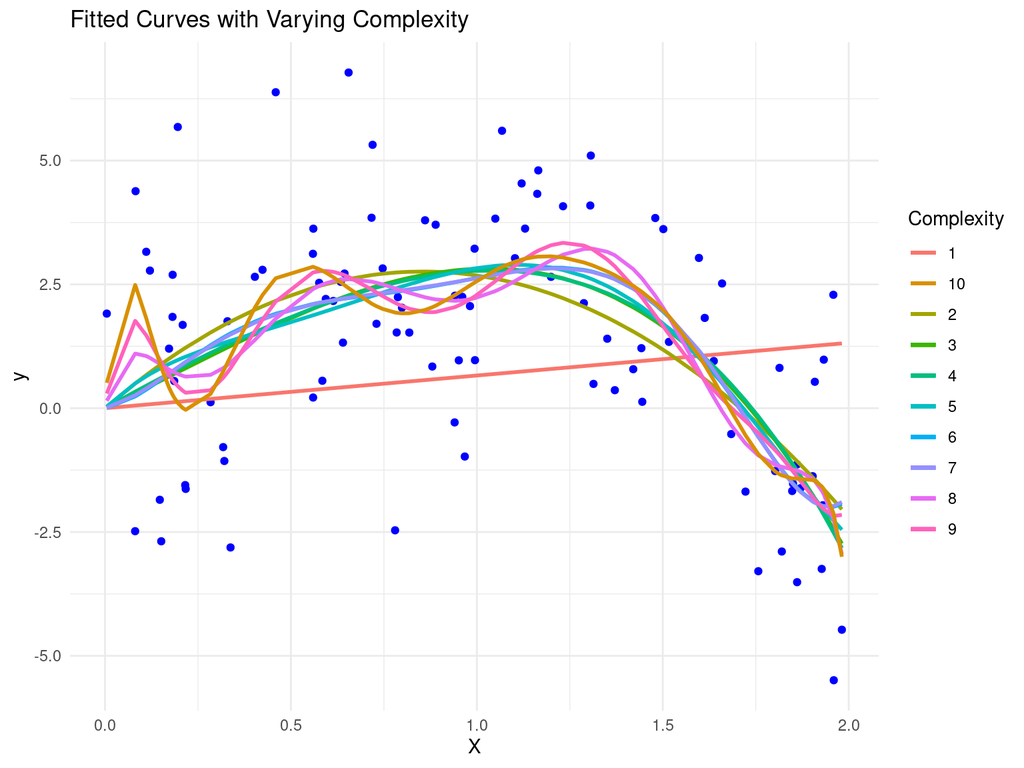

```r
library(ggplot2)
n <- 100
X <- 2 * runif(n, min = 0, max = 1)
y <- 2*X^4 - 8*X^3 + 6*X^2 + 3*X + rnorm(n, mean = 0, sd = 2) # Polynomial relationship of degree 4 with added noise


# Create empty plot
p <- ggplot() +
  geom_point(data = data.frame(X = X, y = y), aes(x = X, y = y), color = "blue") +
  labs(x = "X", y = "y", color = "Complexity") +
  ggtitle("Fitted Curves with Varying Complexity") +
  theme_minimal()

# Function to add fitted curves to the plot
add_curve_to_plot <- function(degree, plot) {
  poly_features <- poly(X, degree, raw = TRUE)
  model <- lm(y ~ poly_features - 1)  # -1 removes intercept term
  predictions <- predict(model, data.frame(poly_features = poly(X, degree, raw = TRUE)))

  # Add fitted curve to the plot
  plot + geom_line(aes(y = predictions, x = X, color = as.factor(degree)), size = 1) +
    scale_color_discrete(name = "Complexity")
}

# Add fitted curves to the plot for degrees 1 to 10
for (degree in 1:10) {
  p <- add_curve_to_plot(degree, p)
}
# Print the final plot
print(p)
```

- What do you observe?

# test MSE and train MSE

- Let’s see how the test and train error would look like

```r
set.seed(42)

# Generate synthetic data with more noise
n <- 100
X <- 2 * runif(n, min = 0, max = 1)
y <- 2*X^4 - 8*X^3 + 6*X^2 + 3*X + rnorm(n, mean = 0, sd = 2) # Polynomial relationship of degree 4 with added noise


# Split the data into training and testing sets
train_indices <- sample(1:n, n * 0.8)
X_train <- X[train_indices]
y_train <- y[train_indices]
X_test <- X[-train_indices]
y_test <- y[-train_indices]

# Function to fit polynomial regression and calculate MSE
fit_polynomial <- function(degree, X_train, y_train, X_test, y_test) {
  poly_features_train <- poly(X_train, degree, raw = TRUE)
  poly_features_test <- poly(X_test, degree, raw = TRUE)
  model <- lm(y_train ~ poly_features_train - 1)  # -1 removes intercept term

  predictions_train <- predict(model, data.frame(poly_features_train = poly_features_train))
  predictions_test <- predict(model, data.frame(poly_features_test = poly_features_test))

  mse_train <- mean((y_train - predictions_train)^2)
  mse_test <- mean((y_test - predictions_test)^2)

  return(c(mse_train, mse_test))
}

# Compute MSE for degrees 1 to 10
degrees <- 1:10
mse_values <- t(sapply(degrees, fit_polynomial, X_train, y_train, X_test, y_test))
```

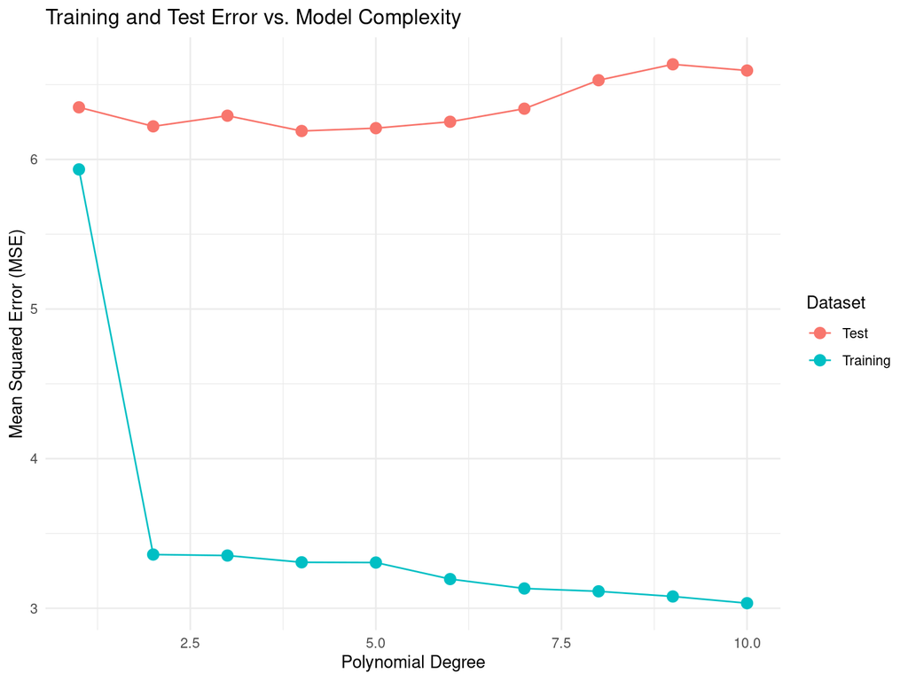

```r
# Create a plot for training and test error
plot_data <- data.frame(Degree = rep(degrees, 2),
                        MSE = c(mse_values[, 1], mse_values[, 2]),
                        Dataset = rep(c("Training", "Test"), each = 10))

ggplot(plot_data, aes(x = Degree, y = MSE, color = Dataset)) +
  geom_line() +
  geom_point(size = 3) +
  labs(x = "Polynomial Degree", y = "Mean Squared Error (MSE)") +
  ggtitle("Training and Test Error vs. Model Complexity") +
  theme_minimal()
```

- What do you observe?